# DATA608-Module1-inc5000

Michael Y.

2/13/2020

**Principles of Data Visualization and Introduction to ggplot2**

I have provided you with data about the 5,000 fastest growing companies in the US, as compiled by Inc. magazine. lets read this in:

```r
path <-
"https://raw.githubusercontent.com/charleyferrari/CUNY_DATA_608/master/module1/Data/inc5000_data.csv"
inc <- read.csv(path,header= TRUE)
```

## Let’s preview this data:

```r
options(digits=7,scipen=999,width=120)
library(kableExtra)
head(inc) %>%
  kable(format.args = list(big.mark = ",")) %>%
  kable_styling(c("bordered","striped"))
```

| Rank | Name | Growth_Rate | Revenue | Industry | Employees | City | State |
| --- | --- | --- | --- | --- | --- | --- | --- |
| 1 | Fuhu | 421.48 | 117,900,000 | Consumer Products & Services | 104 | El Segundo | CA |
| 2 | FederalConference.com | 248.31 | 49,600,000 | Government Services | 51 | Dumfries | VA |
| 3 | The HCI Group | 245.45 | 25,500,000 | Health | 132 | Jacksonville | FL |
| 4 | Bridger | 233.08 | 1,900,000,000 | Energy | 50 | Addison | TX |
| 5 | DataXu | 213.37 | 87,000,000 | Advertising & Marketing | 220 | Boston | MA |
| 6 | MileStone Community Builders | 179.38 | 45,700,000 | Real Estate | 63 | Austin | TX |

```r
summary(inc)
```

```
##       Rank                          Name       Growth_Rate         Revenue
##  Min.   :   1   (Add)ventures         :   1   Min.   :  0.340   Min.   :    2000000
##  1st Qu.:1252   @Properties           :   1   1st Qu.:  0.770   1st Qu.:    5100000
##  Median :2502   1-Stop Translation USA:   1   Median :  1.420   Median :   10900000
##  Mean   :2502   110 Consulting        :   1   Mean   :  4.612   Mean   :   48222535
##  3rd Qu.:3751   11thStreetCoffee.com  :   1   3rd Qu.:  3.290   3rd Qu.:   28600000
##  Max.   :5000   123 Exteriors         :   1   Max.   :421.480   Max.   :10100000000
##                 (Other)               :4995
##                          Industry      Employees                  City          State
##  IT Services                 : 733   Min.   :    1.0   New York     : 160   CA     : 701
##  Business Products & Services: 482   1st Qu.:   25.0   Chicago      :  90   TX     : 387
##  Advertising & Marketing     : 471   Median :   53.0   Austin       :  88   NY     : 311
##  Health                      : 355   Mean   :  232.7   Houston      :  76   VA     : 283
##  Software                    : 342   3rd Qu.:  132.0   San Francisco:  75   FL     : 282
##  Financial Services          : 260   Max.   :66803.0   Atlanta      :  74   IL     : 273
##  (Other)                     :2358   NA's   :12        (Other)      :4438   (Other):2764
```

Think a bit on what these summaries mean. Use the space below to add some more relevant non-visual exploratory information you think helps you understand this data:

```r
# Insert your code here, create more chunks as necessary
library(tidyverse)
# Add a column for revenue per employee at each company
inc2 <- inc %>%
  mutate(RevenuePerEmployee = Revenue / Employees)

### Group by Industry
inc2 %>%
  group_by(Industry) -> inc_byIndustry

### Aggregate by Industry
inc_byIndustry %>% summarise(
  N         = n(),
  AvgGrowth = mean(Growth_Rate,na.rm=T),
  AvgRev    = mean(Revenue,na.rm=T),
  TotalRev  = sum(Revenue,na.rm=T),
  AvgEmpl   = mean(Employees,na.rm=T),
  TotalEmpl = sum(Employees,na.rm=T),
  AvgRevPerEmpl = mean(RevenuePerEmployee,na.rm=T),
  MedRevPerEmpl = median(RevenuePerEmployee,na.rm=T)
) -> Summary_byIndustry

### Group by state
inc2 %>%
  group_by(State) -> inc_byState

### Aggregate by state
inc_byState %>% summarise(
  Num_Companies         = n(),
  AvgGrowth = mean(Growth_Rate,na.rm=T),
  AvgRev    = mean(Revenue,na.rm=T),
  TotalRev  = sum(Revenue,na.rm=T),
  AvgEmpl  = mean(Employees,na.rm=T),
  TotalEmpl = sum(Employees,na.rm=T),
  AvgRevPerEmpl = mean(RevenuePerEmployee,na.rm=T),
  MedRevPerEmpl = median(RevenuePerEmployee,na.rm=T)
) -> Summary_byState
```

### Display summary by industry

```r
options(digits = 10)
Summary_byIndustry %>%
  kable(format.args = list(big.mark = ","),digits=2) %>%
  kable_styling(c("bordered","striped"))
```

| Industry | N | AvgGrowth | AvgRev | TotalRev | AvgEmpl | TotalEmpl | AvgRevPerEmpl | MedRevPerEmpl |
| --- | --- | --- | --- | --- | --- | --- | --- | --- |
| Advertising & Marketing | 471 | 6.23 | 16,528,662.42 | 7,785,000,000 | 84.35 | 39,731 | 306,036.31 | 202,061.86 |
| Business Products & Services | 482 | 3.52 | 54,705,186.72 | 26,367,900,000 | 244.49 | 117,357 | 359,096.93 | 200,000.00 |
| Computer Hardware | 44 | 4.09 | 270,129,545.45 | 11,885,700,000 | 220.77 | 9,714 | 817,702.22 | 516,477.27 |
| Construction | 187 | 3.37 | 70,450,802.14 | 13,174,300,000 | 155.61 | 29,099 | 465,682.41 | 280,000.00 |
| Consumer Products & Services | 203 | 8.78 | 73,676,847.29 | 14,956,400,000 | 223.96 | 45,464 | 466,068.10 | 313,043.48 |
| Education | 83 | 3.64 | 13,726,506.02 | 1,139,300,000 | 92.59 | 7,685 | 296,453.51 | 166,666.67 |
| Energy | 109 | 9.60 | 126,344,954.13 | 13,771,600,000 | 242.54 | 26,437 | 1,554,655.82 | 283,211.68 |
| Engineering | 74 | 1.98 | 34,222,972.97 | 2,532,500,000 | 276.15 | 20,435 | 201,119.95 | 164,840.86 |
| Environmental Services | 51 | 2.07 | 51,741,176.47 | 2,638,800,000 | 199.12 | 10,155 | 283,607.34 | 179,723.50 |
| Financial Services | 260 | 5.44 | 50,580,384.62 | 13,150,900,000 | 183.43 | 47,693 | 394,230.87 | 214,858.48 |
| Food & Beverage | 131 | 3.64 | 98,559,541.98 | 12,911,300,000 | 510.94 | 65,911 | 618,382.85 | 231,372.55 |
| Government Services | 202 | 7.24 | 29,748,019.80 | 6,009,100,000 | 129.63 | 26,185 | 243,596.00 | 165,323.89 |
| Health | 355 | 4.86 | 50,319,436.62 | 17,863,400,000 | 232.85 | 82,430 | 325,198.89 | 174,166.67 |
| Human Resources | 196 | 3.30 | 47,173,979.59 | 9,246,100,000 | 1,158.06 | 226,980 | 395,972.25 | 149,547.51 |
| Insurance | 50 | 2.01 | 46,758,000.00 | 2,337,900,000 | 146.78 | 7,339 | 474,966.36 | 225,622.97 |
| IT Services | 733 | 3.33 | 28,214,597.54 | 20,681,300,000 | 140.42 | 102,788 | 270,494.21 | 163,914.89 |
| Logistics & Transportation | 155 | 4.34 | 95,745,161.29 | 14,840,500,000 | 259.70 | 39,994 | 794,810.91 | 425,024.15 |
| Manufacturing | 256 | 2.30 | 49,546,875.00 | 12,684,000,000 | 172.32 | 43,942 | 453,524.01 | 231,250.00 |
| Media | 54 | 4.37 | 32,266,666.67 | 1,742,400,000 | 176.52 | 9,532 | 307,143.79 | 261,458.33 |
| Real Estate | 96 | 7.75 | 30,892,708.33 | 2,965,700,000 | 198.87 | 18,893 | 434,515.57 | 253,571.43 |
| Retail | 203 | 6.18 | 50,529,064.04 | 10,257,400,000 | 182.60 | 37,068 | 412,554.86 | 312,755.10 |
| Security | 73 | 3.39 | 52,230,136.99 | 3,812,800,000 | 562.45 | 41,059 | 283,391.38 | 158,744.39 |
| Software | 342 | 5.02 | 23,802,923.98 | 8,140,600,000 | 150.33 | 51,262 | 225,989.25 | 155,319.15 |
| Telecommunications | 129 | 2.88 | 56,855,813.95 | 7,334,400,000 | 242.85 | 30,842 | 449,259.60 | 284,000.00 |
| Travel & Hospitality | 62 | 2.35 | 47,283,870.97 | 2,931,600,000 | 371.53 | 23,035 | 414,788.11 | 224,404.76 |

### Display summary by state

```r
Summary_byState[1:26,] %>%
  kable(format.args = list(big.mark = ","),digits=2) %>%
  kable_styling(c("bordered","striped"))
```

| State | Num_Companies | AvgGrowth | AvgRev | TotalRev | AvgEmpl | TotalEmpl | AvgRevPerEmpl | MedRevPerEmpl |
| --- | --- | --- | --- | --- | --- | --- | --- | --- |
| AK | 2 | 4.80 | 171,500,000.00 | 343,000,000 | 1,264.00 | 2,528 | 154,669.98 | 154,669.98 |
| AL | 51 | 2.41 | 25,907,843.14 | 1,321,300,000 | 125.35 | 6,393 | 249,273.67 | 194,059.41 |
| AR | 9 | 1.67 | 8,333,333.33 | 75,000,000 | 55.11 | 496 | 180,752.59 | 154,761.90 |
| AZ | 100 | 4.62 | 55,015,000.00 | 5,501,500,000 | 342.81 | 34,281 | 314,132.28 | 190,814.85 |
| CA | 701 | 5.90 | 33,463,480.74 | 23,457,900,000 | 230.31 | 161,219 | 407,764.93 | 222,967.03 |
| CO | 134 | 4.95 | 31,270,149.25 | 4,190,200,000 | 198.78 | 26,438 | 418,053.48 | 176,086.96 |
| CT | 50 | 4.99 | 49,486,000.00 | 2,474,300,000 | 139.78 | 6,989 | 595,983.46 | 218,750.00 |
| DC | 43 | 8.30 | 76,344,186.05 | 3,282,800,000 | 219.55 | 9,221 | 309,673.37 | 195,652.17 |
| DE | 16 | 2.42 | 42,300,000.00 | 676,800,000 | 4,284.00 | 68,544 | 261,811.20 | 98,250.08 |
| FL | 282 | 5.85 | 37,625,177.30 | 10,610,300,000 | 217.10 | 61,221 | 409,142.84 | 191,153.85 |
| GA | 212 | 3.52 | 30,510,849.06 | 6,468,300,000 | 163.73 | 34,546 | 417,074.41 | 216,666.67 |
| HI | 7 | 6.79 | 99,485,714.29 | 696,400,000 | 88.71 | 621 | 1,001,869.05 | 366,428.57 |
| IA | 28 | 1.76 | 123,142,857.14 | 3,448,000,000 | 405.14 | 11,344 | 337,214.61 | 218,436.29 |
| ID | 17 | 2.65 | 231,523,529.41 | 3,935,900,000 | 342.18 | 5,817 | 675,024.18 | 271,428.57 |
| IL | 273 | 3.74 | 121,773,992.67 | 33,244,300,000 | 379.65 | 103,266 | 462,003.12 | 216,447.09 |
| IN | 69 | 4.79 | 50,105,797.10 | 3,457,300,000 | 184.01 | 12,697 | 281,487.24 | 164,516.13 |
| KS | 38 | 3.63 | 40,752,631.58 | 1,548,600,000 | 229.61 | 8,725 | 480,676.68 | 167,715.73 |
| KY | 40 | 2.06 | 33,232,500.00 | 1,329,300,000 | 138.60 | 5,544 | 435,194.31 | 198,015.87 |
| LA | 37 | 1.94 | 56,648,648.65 | 2,096,000,000 | 288.35 | 10,669 | 271,525.50 | 166,666.67 |
| MA | 182 | 5.42 | 33,174,725.27 | 6,037,800,000 | 135.62 | 24,682 | 336,959.11 | 200,000.00 |
| MD | 131 | 4.98 | 25,193,893.13 | 3,300,400,000 | 308.69 | 40,439 | 269,938.18 | 183,428.57 |
| ME | 13 | 16.21 | 12,476,923.08 | 162,200,000 | 67.62 | 879 | 293,313.56 | 157,777.78 |
| MI | 126 | 2.24 | 61,950,793.65 | 7,805,800,000 | 292.90 | 36,905 | 294,574.44 | 153,887.46 |
| MN | 88 | 3.82 | 57,256,818.18 | 5,038,600,000 | 210.61 | 18,534 | 510,810.49 | 186,144.07 |
| MO | 59 | 2.50 | 45,164,406.78 | 2,664,700,000 | 293.15 | 17,296 | 408,161.70 | 265,217.39 |
| MS | 12 | 5.64 | 43,766,666.67 | 525,200,000 | 460.92 | 5,531 | 611,781.75 | 288,038.28 |

```r
Summary_byState[27:52,] %>%
  kable(format.args = list(big.mark = ","),digits=2) %>%
  kable_styling(c("bordered","striped"))
```

| State | Num_Companies | AvgGrowth | AvgRev | TotalRev | AvgEmpl | TotalEmpl | AvgRevPerEmpl | MedRevPerEmpl |
| --- | --- | --- | --- | --- | --- | --- | --- | --- |
| MT | 4 | 0.76 | 6,150,000.00 | 24,600,000 | 418.25 | 1,673 | 264,333.47 | 246,187.36 |
| NC | 137 | 3.51 | 67,580,291.97 | 9,258,500,000 | 271.74 | 36,685 | 307,454.39 | 181,382.98 |
| ND | 10 | 1.23 | 18,240,000.00 | 182,400,000 | 96.30 | 963 | 230,156.51 | 245,285.17 |
| NE | 27 | 2.08 | 40,696,296.30 | 1,098,800,000 | 141.59 | 3,823 | 382,766.77 | 203,076.92 |
| NH | 24 | 1.51 | 41,691,666.67 | 1,000,600,000 | 120.42 | 2,890 | 427,787.67 | 310,344.83 |
| NJ | 158 | 4.45 | 29,574,683.54 | 4,672,800,000 | 190.90 | 30,162 | 357,740.83 | 179,261.36 |
| NM | 5 | 1.36 | 9,640,000.00 | 48,200,000 | 123.40 | 617 | 133,085.46 | 135,000.00 |
| NV | 26 | 2.33 | 19,915,384.62 | 517,800,000 | 66.35 | 1,725 | 418,628.12 | 213,116.88 |
| NY | 311 | 4.37 | 58,715,112.54 | 18,260,400,000 | 271.29 | 84,370 | 495,851.34 | 200,000.00 |
| OH | 186 | 3.56 | 68,745,161.29 | 12,786,600,000 | 204.31 | 38,002 | 490,292.92 | 230,958.39 |
| OK | 46 | 3.10 | 41,015,217.39 | 1,886,700,000 | 151.65 | 6,976 | 321,872.32 | 256,220.10 |
| OR | 49 | 3.15 | 28,589,795.92 | 1,400,900,000 | 89.78 | 4,399 | 355,951.88 | 192,307.69 |
| PA | 164 | 2.57 | 34,568,902.44 | 5,669,300,000 | 186.45 | 30,392 | 285,522.91 | 195,918.37 |
| PR | 1 | 1.73 | 2,300,000.00 | 2,300,000 | 29.00 | 29 | 79,310.34 | 79,310.34 |
| RI | 16 | 16.03 | 46,981,250.00 | 751,700,000 | 185.25 | 2,964 | 337,965.65 | 183,571.43 |
| SC | 48 | 6.06 | 30,993,750.00 | 1,487,700,000 | 111.42 | 5,348 | 317,050.73 | 222,162.16 |
| SD | 3 | 1.41 | 5,900,000.00 | 17,700,000 | 253.67 | 761 | 72,534.37 | 67,647.06 |
| TN | 82 | 4.95 | 35,870,731.71 | 2,941,400,000 | 177.88 | 14,586 | 458,637.47 | 190,109.88 |
| TX | 387 | 6.02 | 57,271,834.63 | 22,164,200,000 | 235.14 | 90,765 | 499,383.92 | 196,168.41 |
| UT | 95 | 6.31 | 36,038,947.37 | 3,423,700,000 | 200.29 | 19,028 | 356,986.20 | 172,195.12 |
| VA | 283 | 4.88 | 30,627,915.19 | 8,667,700,000 | 126.03 | 35,667 | 298,791.42 | 174,545.45 |
| VT | 6 | 1.30 | 46,200,000.00 | 277,200,000 | 178.17 | 1,069 | 275,514.23 | 237,422.71 |
| WA | 130 | 4.00 | 27,156,923.08 | 3,530,400,000 | 135.01 | 17,416 | 255,218.89 | 181,374.72 |
| WI | 79 | 2.69 | 92,362,025.32 | 7,296,600,000 | 201.92 | 15,548 | 390,960.27 | 202,127.66 |
| WV | 2 | 0.62 | 15,650,000.00 | 31,300,000 | 120.00 | 240 | 109,674.55 | 109,674.55 |
| WY | 2 | 19.14 | 34,750,000.00 | 69,500,000 | 53.50 | 107 | 568,315.02 | 568,315.02 |

## Question 1

Create a graph that shows the distribution of companies in the dataset by State (ie how many are in each state). There are a lot of States, so consider which axis you should use. This visualization is ultimately going to be consumed on a ‘portrait’ oriented screen (ie taller than wide), which should further guide your layout choices.

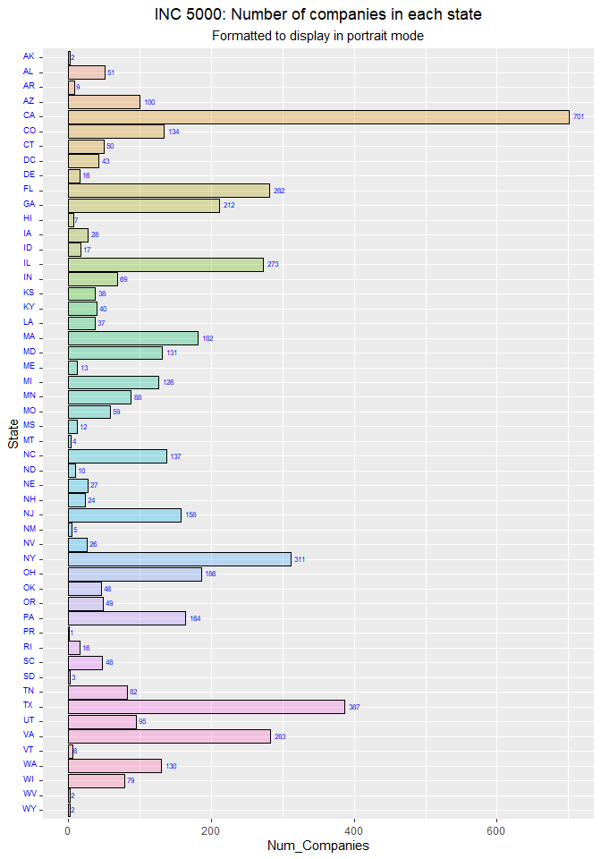

```r
# Answer Question 1 here

## Select just the State name and the number of companies
tempgrid <- Summary_byState  %>% select (State,Num_Companies)

## Reverse the grid so the results will display alphabetically (rather than backwards)
tempgrid <- tempgrid[rev(tempgrid$State),]


ggplot(tempgrid, aes(x=State, y=Num_Companies, fill=State))+
geom_col(position=position_dodge(+.5),color="black", alpha=0.3) +
geom_text( aes(label=Num_Companies), hjust=-0.4, vjust=+0.3, color="blue",
   size=2) +
ggtitle(label="INC 5000: Number of companies in each state",
        subtitle="Formatted to display in portrait mode") +
scale_x_discrete(limits = rev(levels(tempgrid$State)))+
theme(axis.text.y = element_text(angle = 0,
                                 hjust = +0.1, vjust=+0.1,
                                 size=7,color="blue"))+
theme(plot.title = element_text(hjust = 0.5))+
theme(plot.subtitle = element_text(hjust = 0.5))+
theme(legend.position="none")+
coord_flip()
```

## Question 2

Lets dig in on the state with the 3rd most companies in the data set. Imagine you work for the state and are interested in how many people are employed by companies in different industries. Create a plot that shows the average and/or median employment by industry for companies in this state (only use cases with full data, use R’s `complete.cases()` function.) In addition to this, your graph should show how variable the ranges are, and you should deal with outliers.

```r
# Answer Question 2 here

### Determine which state has the 3rd most companies
whichRow <- order(Summary_byState$Num_Companies,decreasing = T)[3]
whichState <- as.character(Summary_byState$State)[whichRow]
numCompanies  <- as.integer(Summary_byState[whichRow,"Num_Companies"])
print(paste0("The state with the 3rd most companies is ",
             whichState, " with ", numCompanies, " companies."))
```

```
## [1] "The state with the 3rd most companies is NY with 311 companies."
```

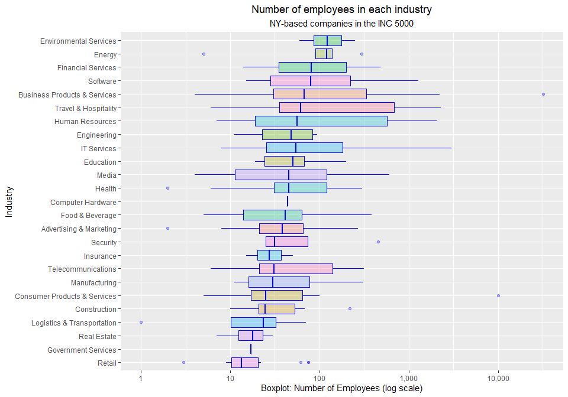

```r
### Subset the dataset with companies just from that state
inc2 %>% filter(State==whichState) -> inc3
### Filter out any cases with NA values  [ for this example, there are no such cases]
inc3 <- inc3[complete.cases(inc3),]
ggplot(inc3, aes(x = reorder(x=Industry,
                             X=Employees,
                             FUN = median),
                 y = Employees,
                 fill=Industry)) +
  geom_boxplot(color="blue", alpha=0.3) +
  scale_y_log10(label=scales::comma_format(accuracy = 1)) +
  labs(x="Industry",
       y="Boxplot: Number of Employees (log scale)",
       title = "Number of employees in each industry",
       subtitle = "NY-based companies in the INC 5000")+
  theme(plot.title = element_text(hjust = 0.5))+
  theme(plot.subtitle = element_text(hjust = 0.5))+
  theme(legend.position="none")+
  coord_flip()
```

## Question 3

Now imagine you work for an investor and want to see which industries generate the most revenue per employee. Create a chart that makes this information clear. Once again, the distribution per industry should be shown.

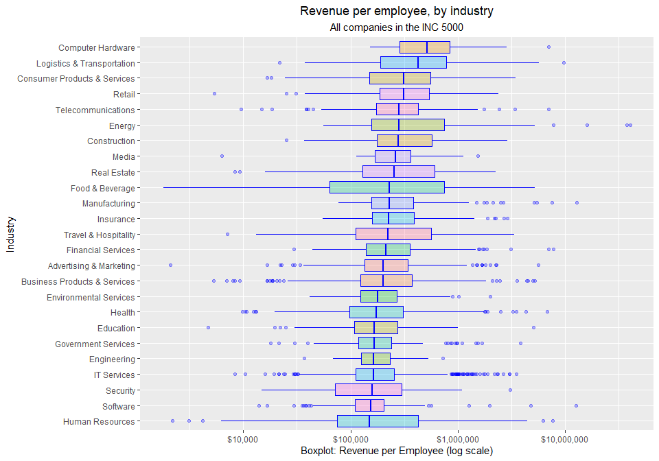

```r
# Answer Question 3 here

# Add a column for revenue per employee at each company
inc4 <- inc %>% mutate(RevenuePerEmployee = Revenue / Employees)

# There are 12 companies for which the number of employees is unknown.
# Drop them.
inc4 <- inc4[complete.cases(inc4),]



ggplot(inc4, aes(x = reorder(x=Industry,
                             X=RevenuePerEmployee,
                             FUN = median),
                 y = RevenuePerEmployee,
                 fill=Industry)) +
  geom_boxplot(color="blue", alpha=0.3) +
  scale_y_log10(label=scales::dollar_format(accuracy = 1)) +
  labs(x="Industry",
       y="Boxplot: Revenue per Employee (log scale)",
       title = "Revenue per employee, by industry",
       subtitle = "All companies in the INC 5000")+
  theme(plot.title = element_text(hjust = 0.5))+
  theme(plot.subtitle = element_text(hjust = 0.5))+
  theme(legend.position="none")+
  coord_flip()
```